# statnet

Maria Prokofieva

20/02/2021

## `statnet` package

[`statnet`](https://cran.r-project.org/web/packages/statnet/index.html) package includes several R other packages tailored for the analysis of social networks and other relational data.

In this tutorial we are going to cover just basics of using this package. We will focus on the following *very basic packages* included in `statnet` package:

- `network` package: a package to create, store, modify and plot the data in network objects. T
- `sna` package: a package for traditional social network analysis.

You can see the list of all packages included in `statnet` [here](https://cran.r-project.org/web/packages/statnet/statnet.pdf).

There are ample resources for this package, such as

- [statnet workshops](https://github.com/statnet/Workshops/wiki)

### Network object

`statnet` works with the `network object class`, defined in the network package. It works with various relational data types. Once the network object is created it can e analysed further using other parts (=packages) in `statnet`.

**Network object**: stores an adjacency matrix or an edgelist as well as metadata.

*Metadata*: vertex, edge, and network attributes

We are going to have a look at one of the in-built datasets in the `network` package: `flo`

`flo` is a dataset of Padgett (1994), consisting of weddings among leading Florentine families. The data is provided in the symmetric adjacency matrix form.

```r
data(flo)
```

```r
family<-network(flo, directed=FALSE)

class(family)
```

```
## [1] "network"
```

To create a network object we use `network()` function from the `network` (`statnet`) package

The function has the following syntax:

```r
network(x, vertex.attr = NULL, vertex.attrnames = NULL,
  directed = TRUE, hyper = FALSE, loops = FALSE, multiple = FALSE,
  bipartite = FALSE, ...)
```

where

- `x` is a matrix with the network structure in adjacency, incidence or edgelist form.
- `vertex.attr` and `vertex.attrnames` are optional lists with vertex attributes and vertex attributes names
- `directed` specifies if edges are directed

To have a look at the network we can use `summary()` function

```r
summary(family)
```

```
## Network attributes:
##   vertices = 16
##   directed = FALSE
##   hyper = FALSE
##   loops = FALSE
##   multiple = FALSE
##   bipartite = FALSE
##  total edges = 20
##    missing edges = 0
##    non-missing edges = 20
##  density = 0.1666667
##
## Vertex attributes:
##   vertex.names:
##    character valued attribute
##    16 valid vertex names
##
## No edge attributes
##
## Network edgelist matrix:
##       [,1] [,2]
##  [1,]    9    1
##  [2,]    6    2
##  [3,]    7    2
##  [4,]    9    2
##  [5,]    5    3
##  [6,]    9    3
##  [7,]    7    4
##  [8,]   11    4
##  [9,]   15    4
## [10,]   11    5
## [11,]   15    5
## [12,]    8    7
## [13,]   16    7
## [14,]   13    9
## [15,]   14    9
## [16,]   16    9
## [17,]   14   10
## [18,]   15   11
## [19,]   15   13
## [20,]   16   13
```

We can visualize the network using `gplot()` function from the `sna` package:

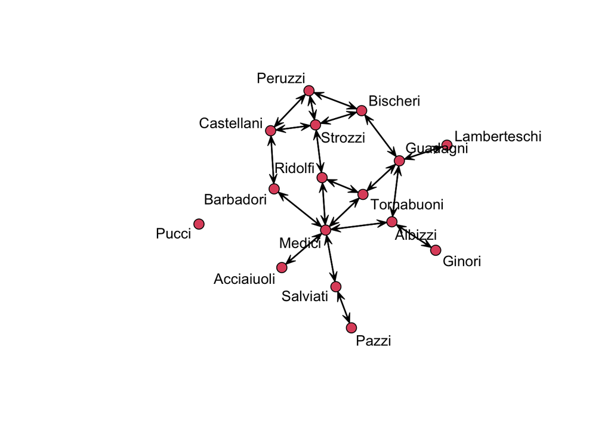

```r
gplot(family, vertex.col = 2, displaylabels = TRUE)
```

`gplot` produces nice two-dimensional plots and comes with a variety of options to control vertex placement, display details, color, etc.

### Working with edges

We can create an empty network object using `network.initialize(n)` with n vertices:

```r
new_network<-network.initialize(5)
class(new_network)
```

```
## [1] "network"
```

```r
summary(new_network)
```

```
## Network attributes:
##   vertices = 5
##   directed = TRUE
##   hyper = FALSE
##   loops = FALSE
##   multiple = FALSE
##   bipartite = FALSE
##  total edges = 0
##    missing edges = 0
##    non-missing edges = 0
##  density = 0
##
## Vertex attributes:
##   vertex.names:
##    character valued attribute
##    5 valid vertex names
##
## No edge attributes
##
## Network adjacency matrix:
## Empty Graph
```

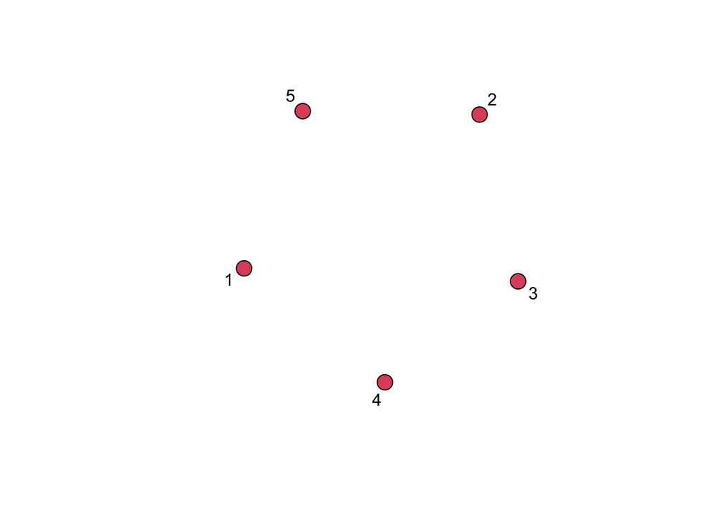

```r
gplot(new_network, displaylabels = TRUE)
```

We can add edges to the network object and remove them

```r
new_network[1,2]<-3 #Add an edge from 1 to 2
new_network[4,5]<-2#Add an edge from 4 to 5
summary(new_network)
```

```
## Network attributes:
##   vertices = 5
##   directed = TRUE
##   hyper = FALSE
##   loops = FALSE
##   multiple = FALSE
##   bipartite = FALSE
##  total edges = 2
##    missing edges = 0
##    non-missing edges = 2
##  density = 0.1
##
## Vertex attributes:
##   vertex.names:
##    character valued attribute
##    5 valid vertex names
##
## No edge attributes
##
## Network adjacency matrix:
##   1 2 3 4 5
## 1 0 1 0 0 0
## 2 0 0 0 0 0
## 3 0 0 0 0 0
## 4 0 0 0 0 1
## 5 0 0 0 0 0
```

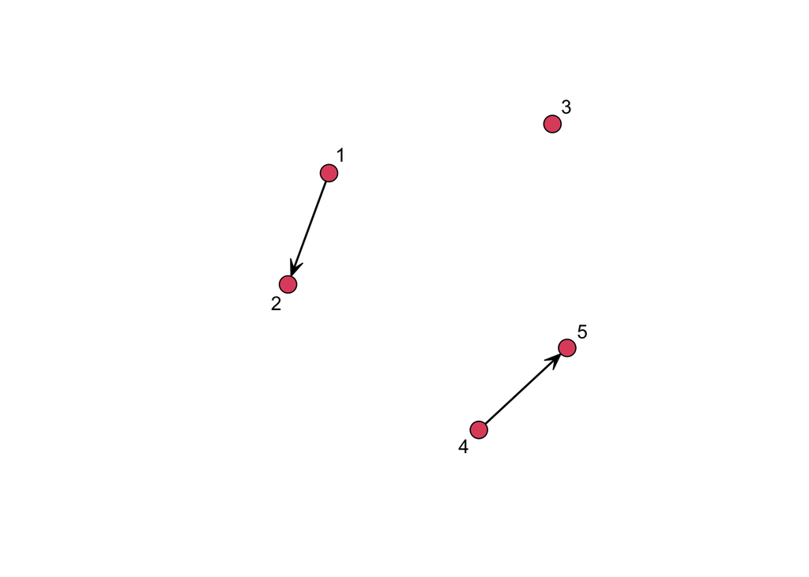

```r
gplot(new_network, displaylabels = TRUE) #Plot with names
```

```r
new_network #Examine the result
```

```
##  Network attributes:
##   vertices = 5
##   directed = TRUE
##   hyper = FALSE
##   loops = FALSE
##   multiple = FALSE
##   bipartite = FALSE
##   total edges= 2
##     missing edges= 0
##     non-missing edges= 2
##
##  Vertex attribute names:
##     vertex.names
##
## No edge attributes
```

To remove the edge

```r
new_network[1,2] <- 0 #Remove the edge from 1 to 2
new_network
```

```
##  Network attributes:
##   vertices = 5
##   directed = TRUE
##   hyper = FALSE
##   loops = FALSE
##   multiple = FALSE
##   bipartite = FALSE
##   total edges= 1
##     missing edges= 0
##     non-missing edges= 1
##
##  Vertex attribute names:
##     vertex.names
##
## No edge attributes
```

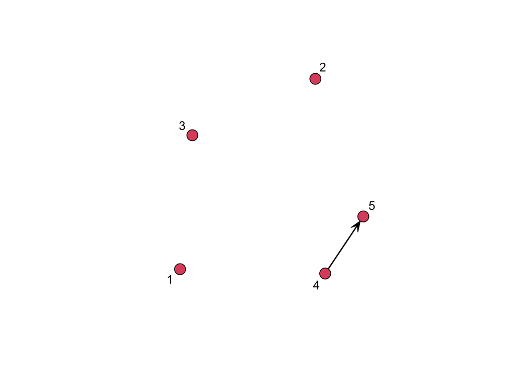

```r
gplot(new_network, displaylabels = TRUE) #Plot with names
```

### Description and Visualization

Apart from the `summary()` function to get the overall summary of the network we can use the following functions:

```r
network.size(family) #How large is the network?

network.edgecount(family) #How many edges are present?

plot(family,displaylabels=T,boxed.labels=F) #Plot with names
```

[output not shown]

### Working with attributes (=vertex attributes)

To see a vector of attribute values for vertices use `get.vertex.attribute()`, or its shortcut, `%v%`:

```r
family %v% 'woo' <- letters[1:16] # Same as set.vertex.attribute
family
```

```
##  Network attributes:
##   vertices = 16
##   directed = FALSE
##   hyper = FALSE
##   loops = FALSE
##   multiple = FALSE
##   bipartite = FALSE
##   total edges= 20
##     missing edges= 0
##     non-missing edges= 20
##
##  Vertex attribute names:
##     vertex.names woo
##
## No edge attributes
```

```r
family %v% 'woo' #same as get.vertex.attribute
```

```
##  [1] "a" "b" "c" "d" "e" "f" "g" "h" "i" "j" "k" "l" "m" "n" "o" "p"
```

```r
new_network %v% 'gender'<-c("F","F","M", "M", "F")
new_network
```

```
##  Network attributes:
##   vertices = 5
##   directed = TRUE
##   hyper = FALSE
##   loops = FALSE
##   multiple = FALSE
##   bipartite = FALSE
##   total edges= 1
##     missing edges= 0
##     non-missing edges= 1
##
##  Vertex attribute names:
##     gender vertex.names
##
## No edge attributes
```

```r
new_network %v% 'gender'
```

```
## [1] "F" "F" "M" "M" "F"
```

Information about tie (=edges) characteristics is stored and managed in the network objects, using the similarly named `set.edge.attributes()` and `get.edge.attributes()` functions.

```r
new_network
```

```
##  Network attributes:
##   vertices = 5
##   directed = TRUE
##   hyper = FALSE
##   loops = FALSE
##   multiple = FALSE
##   bipartite = FALSE
##   total edges= 1
##     missing edges= 0
##     non-missing edges= 1
##
##  Vertex attribute names:
##     gender vertex.names
##
## No edge attributes
```

```r
list.edge.attributes(new_network)
```

```
## [1] "na"
```

```r
set.edge.attribute(new_network,"random_value", runif(network.size(new_network),0,1))
list.edge.attributes(new_network)
```

```
## [1] "na"           "random_value"
```

We can use a similar shortcut `%e%` to access edge attributes

```r
summary(new_network %e% "random_value")
```

```
##    Min. 1st Qu.  Median    Mean 3rd Qu.    Max.
##  0.4669  0.4669  0.4669  0.4669  0.4669  0.4669
```

```r
summary(get.edge.attribute(new_network, "random_value"))
```

```
##    Min. 1st Qu.  Median    Mean 3rd Qu.    Max.
##  0.4669  0.4669  0.4669  0.4669  0.4669  0.4669
```